# Topological Data Analysis with Persistent Homology, $1^\text{st}$ tutorial

https://raphaeltinarrage.github.io/EMAp.html

## Lesson IV: Simplicial complexes and topological invariants

Last update: 29/01/2021

# Correction

```python
import gudhi
import numpy as np
import networkx as nx
```

```python
def PrintSimplices(simpcomplex):
    '''
    Print a list of the simplices of the simplicial complex 'simpcomplex'.

    Input:
        simpcomplex: a gudhi.SimplexTree

    Example:
        simpcomplex = gudhi.SimplexTree()
        simpcomplex.insert([0])
        simpcomplex.insert([1])
        PrintSimplices(simpcomplex)
    '''
    simplices = {i:[] for i in range(simpcomplex.dimension()+1)}
    for filtration in simpcomplex.get_simplices():
        simplex = filtration[0]
        simplices[len(simplex)-1].append(simplex)
    print('The simplicial complex contains the following simplices: ')
    for i in range(simpcomplex.dimension()+1):
        print('Dimension '+repr(i)+': ', end="")
        print(*simplices[i], sep = ", ")

def DrawSimplicialComplex(simpcomplex, pos=None):
    '''
    Draw the 1-skeleton of the simplicial complex 'simpcomplex', in the plane.
    If 'pos==None', the position of the vertices are chosen at random, according to the 'spring_layout' of networkx.
    If pos is a dict

    Input:
        simpcomplex: a gudhi.SimplexTree
        pos: a dict {(vertex of simpcomplex): (list of floats of length 2) }

    Example 1:
        simpcomplex = gudhi.SimplexTree()
        simpcomplex.insert([0])
        simpcomplex.insert([1])
        DrawSimplicialComplex(simpcomplex)

    Example 2:
        simpcomplex = gudhi.SimplexTree()
        simpcomplex.insert([0])
        simpcomplex.insert([1])
        pos = {0:[0,0], 1:[0,1]}
        DrawSimplicialComplex(simpcomplex, pos=pos)
    '''
    nodes=[]; edges=[]
    for filtr in simpcomplex.get_skeleton(1):
        simplex = filtr[0]
        if len(simplex)==1:
            nodes.append(simplex[0])
        if len(simplex)==2:
            edges.append(simplex)
    G = nx.Graph()
    G.add_nodes_from(nodes)
    G.add_edges_from(edges)
    if pos == None:
        pos = nx.spring_layout(G)
    nx.draw(G, pos=pos, with_labels=True, font_weight='bold', node_color='magenta')

def NumberOfConnectedComponents(simpcomplex, verbose = 'True'):
    '''
    Print the number of connected components of the simplicial complex 'simpcomplex'.

    Input:
        simpcomplex: a gudhi.SimplexTree

    Example:
        simpcomplex = gudhi.SimplexTree()
        simpcomplex.insert([0])
        simpcomplex.insert([1])
        NumberOfConnectedComponents(simpcomplex)
    '''
    simpcomplex.compute_persistence()
    nbr_components = simpcomplex.betti_numbers()[0]
    if verbose: print('The simplicial complex admits '+repr(nbr_components)+' connected component(s).')
    return nbr_components

def EulerCharacteristic(simpcomplex, verbose = 'True'):
    '''
    Print the Euler characteristic of the simplicial complex 'simpcomplex'.

    Input:
        simpcomplex: a gudhi.SimplexTree

    Example:
        simpcomplex = gudhi.SimplexTree()
        simpcomplex.insert([0])
        simpcomplex.insert([1])
        EulerCharacteristic(simpcomplex)
    '''
    num_simplices = [0 for i in range(simpcomplex.dimension()+1)]
    for filtration in simpcomplex.get_simplices():
        simplex = filtration[0]
        num_simplices[len(simplex)-1]+=1
    Euler_characteristic = sum(num_simplices[::2]) - sum(num_simplices[1::2])
    if verbose: print('The simplicial complex has Euler characteristic equal to '+repr(Euler_characteristic)+'.')
    return Euler_characteristic
```

## Triangulation of the circle

We start by considering a simplicial complex $S$ that is a triangulation of the circle. It is given by:

- three vertices: $0$,$1$ and $2$,
- three edges: $[0,1]$, $[1,2]$ and $[2,0]$.

```python
# We build a SimplexTree structure on gudhi

simpcomplex = gudhi.SimplexTree()
```

```python
# We add the vertices

simpcomplex.insert([0])
simpcomplex.insert([1])
simpcomplex.insert([2])
```

```
True
```

```python
# Let us verify that the vertices are correctly added

PrintSimplices(simpcomplex)
```

```
The simplicial complex contains the following simplices:
Dimension 0: [0], [1], [2]
```

```python
# We add the edges

simpcomplex.insert([0,1])
simpcomplex.insert([1,2])
simpcomplex.insert([2,0])
```

```
True
```

```python
# Let us verify that the edges are correctly added

PrintSimplices(simpcomplex)
```

```
The simplicial complex contains the following simplices:
Dimension 0: [0], [1], [2]
Dimension 1: [0, 1], [0, 2], [1, 2]
```

```python
# In Gudhi, if a simplex is added to the complex, then all its faces are
# Hence we can use the simpler code:

simpcomplex2 = gudhi.SimplexTree()

simpcomplex2.insert([0,1])
simpcomplex2.insert([1,2])
simpcomplex2.insert([2,0])

PrintSimplices(simpcomplex2)
```

```
The simplicial complex contains the following simplices:
Dimension 0: [0], [1], [2]
Dimension 1: [0, 1], [0, 2], [1, 2]
```

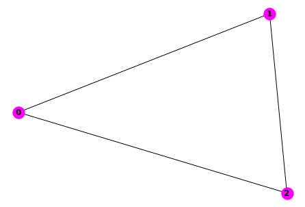

```python
# The following function allows to draw the simplicial complex (uses the library networkx)

DrawSimplicialComplex(simpcomplex)
```

## Computing topological invariants

```python
# The following function returns the number of connected components of the complex.
# Use verbose = 'True' or verbose = 'False' to print the output sentence.

NumberOfConnectedComponents(simpcomplex, verbose = True)
```

```
The simplicial complex admits 1 connected component(s).
```

```
1
```

```python
# The following function returns the Euler characteristic of the complex.
# Use verbose = 'True' or verbose = 'False' to print the output sentence.

EulerCharacteristic(simpcomplex, verbose = True)
```

```
The simplicial complex has Euler characteristic equal to 0.
```

```
0
```

# Exercise 22

Build triangulations of the alphabet letters, and compute their Euler characteristic.

Given two letters that are homotopy equivalent, is it true thar their Euler characteristic are equal? Given two letters that are not homotopy equivalent, is it true thar their Euler characteristic are different?

```
The simplicial complex has Euler characteristic equal to 0.
```

```
0
```

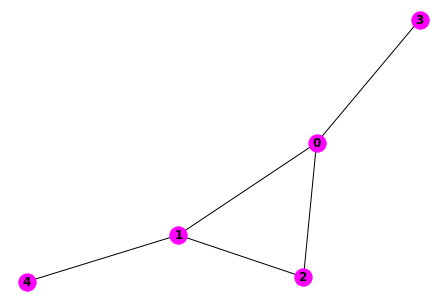

```python
# We build a triangulation of the letter A

simpcomplex = gudhi.SimplexTree()

simpcomplex.insert([0,1])
simpcomplex.insert([1,2])
simpcomplex.insert([2,0])
simpcomplex.insert([3,0])
simpcomplex.insert([4,1])

DrawSimplicialComplex(simpcomplex)
EulerCharacteristic(simpcomplex)
```

```
The simplicial complex has Euler characteristic equal to -1.
```

```
-1
```

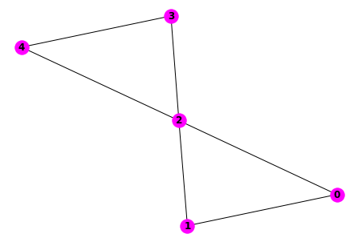

```python
# We build a triangulation of the letter B

simpcomplex = gudhi.SimplexTree()

simpcomplex.insert([0,1])
simpcomplex.insert([1,2])
simpcomplex.insert([2,0])
simpcomplex.insert([2,3])
simpcomplex.insert([3,4])
simpcomplex.insert([4,2])

DrawSimplicialComplex(simpcomplex)
EulerCharacteristic(simpcomplex)
```

```
The simplicial complex has Euler characteristic equal to 1.
```

```
1
```

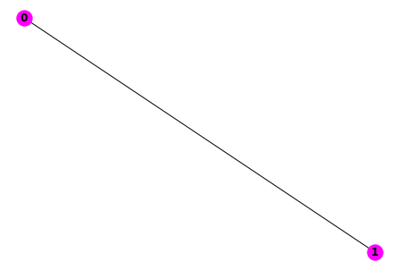

```python
# We build a triangulation of the letter C

simpcomplex = gudhi.SimplexTree()

simpcomplex.insert([0,1])

DrawSimplicialComplex(simpcomplex)
EulerCharacteristic(simpcomplex)
```

```
The simplicial complex has Euler characteristic equal to 0.
```

```
0
```

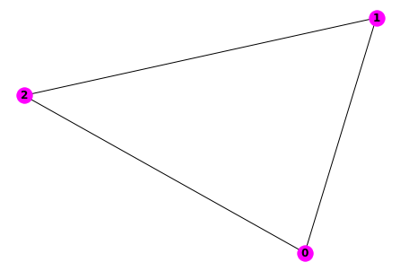

```python
# We build a triangulation of the letter D

simpcomplex = gudhi.SimplexTree()

simpcomplex.insert([0,1])
simpcomplex.insert([1,2])
simpcomplex.insert([2,0])

DrawSimplicialComplex(simpcomplex)
EulerCharacteristic(simpcomplex)
```

```
The simplicial complex has Euler characteristic equal to 1.
```

```
1
```

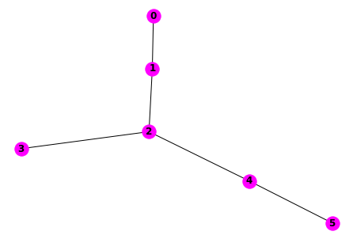

```python
# We build a triangulation of the letter E

simpcomplex = gudhi.SimplexTree()

simpcomplex = gudhi.SimplexTree()
simpcomplex.insert([0,1])
simpcomplex.insert([1,2])
simpcomplex.insert([2,3])
simpcomplex.insert([2,4])
simpcomplex.insert([4,5])

DrawSimplicialComplex(simpcomplex)
EulerCharacteristic(simpcomplex)
```

```
The simplicial complex has Euler characteristic equal to 1.
```

```
1
```

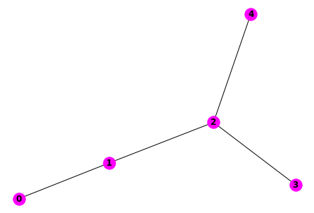

```python
# We build a triangulation of the letter F

simpcomplex = gudhi.SimplexTree()

simpcomplex.insert([0,1])
simpcomplex.insert([1,2])
simpcomplex.insert([2,3])
simpcomplex.insert([2,4])

DrawSimplicialComplex(simpcomplex)
EulerCharacteristic(simpcomplex)
```

```
The simplicial complex has Euler characteristic equal to 1.
```

```
1
```

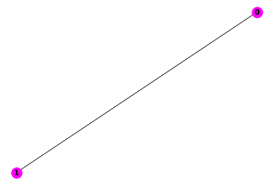

```python
# We build a triangulation of the letter G

simpcomplex = gudhi.SimplexTree()

simpcomplex.insert([0,1])

DrawSimplicialComplex(simpcomplex)
EulerCharacteristic(simpcomplex)
```

```
The simplicial complex has Euler characteristic equal to 1.
```

```
1
```

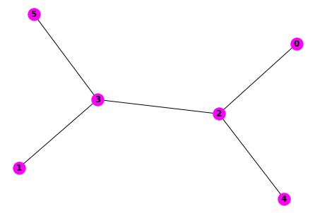

```python
# We build a triangulation of the letter H

simpcomplex = gudhi.SimplexTree()

simpcomplex.insert([0,2])
simpcomplex.insert([1,3])
simpcomplex.insert([2,3])
simpcomplex.insert([2,4])
simpcomplex.insert([3,5])

DrawSimplicialComplex(simpcomplex)
EulerCharacteristic(simpcomplex)
```

# Exercise 23

For every $n$, triangulate the bouquet of $n$ circles. Compute their Euler characteristic.

```
N is equal to 6
The simplicial complex has Euler characteristic equal to -5.
```

```
-5
```

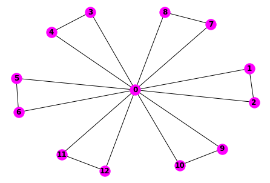

```python
n = 6

sc = gudhi.SimplexTree()

sc.insert([0])

for i in range(n):
    sc.insert([0, 2*i+1])
    sc.insert([0, 2*i+2])
    sc.insert([2*i+1, 2*i+2])

DrawSimplicialComplex(sc)

print('N is equal to '+repr(n))
EulerCharacteristic(sc)
```

It seems like the Euler characteristic of the bouquet of $n$ circles is $1-n$.

# Exercise 24

Implement the triangulation of the torus given in the notes. Compute its Euler characteristic.

```
The simplicial complex has Euler characteristic equal to 0.
```

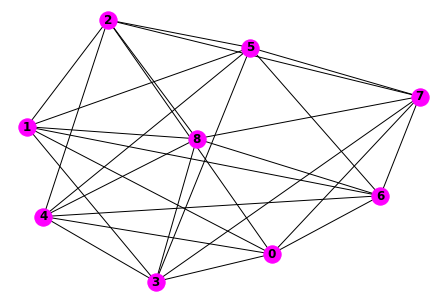

```python
torus = gudhi.SimplexTree()

torus.insert([0,3,7])
torus.insert([0,2,7])
torus.insert([2,7,5])
torus.insert([2,1,5])
torus.insert([1,5,3])
torus.insert([0,1,3])

torus.insert([3,4,8])
torus.insert([3,7,8])
torus.insert([7,8,6])
torus.insert([7,5,6])
torus.insert([5,6,4])
torus.insert([5,4,3])

torus.insert([4,0,2])
torus.insert([4,2,8])
torus.insert([8,2,1])
torus.insert([8,1,6])
torus.insert([6,1,0])
torus.insert([6,4,0])

EulerCharacteristic(torus)

DrawSimplicialComplex(torus)
```

Observe that this is not a faithful representation of the torus (edges intersecting each other).

# Exercise 25

Consider the following dataset of $30$ points $x_0, ..., x_{29}$ in $\mathbb{R}^2$:

```
 {0: [0.29409772548731694, 0.6646626625013836],
 1: [0.01625840776679577, 0.1676405753593595],
 2: [0.15988905150272759, 0.6411323760808338],
 3: [0.9073191075894482, -0.16417982219713312],
 4: [-0.18661467838673884, 0.31618948583046413],
 5: [-0.3664040542098381, 0.9098590694955988],
 6: [-0.43753448716144905, -0.8820102274699417],
 7: [0.4096730199915961, -0.23801426675264126],
 8: [0.5903822103474676, -0.7285102954232894],
 9: [0.9133851839417766, -0.6606557328320093],
 10: [-0.15516122940597588, 0.7565411235103017],
 11: [-0.38626186295039866, -0.3662321656058476],
 12: [0.005209710070218199, 0.27655964872153116],
 13: [0.670078068894711, -0.00932202688834849],
 14: [-0.011268465716772091, 0.24340880308017376],
 15: [-0.6441978411451603, -0.9672635759413206],
 16: [-0.2841794022401025, -0.6734801188906114],
 17: [-0.15473260248990717, -0.1365357396855129],
 18: [0.7177096105982121, 0.9378197891592468],
 19: [-0.4677068504994166, 0.1533930130294956],
 20: [-0.32379909116817096, 0.9694800649768063],
 21: [-0.2886940472879451, -0.039544695812395725],
 22: [-0.5900701743351606, 0.8350804500575086],
 23: [0.14931959728335853, 0.869106793774487],
 24: [-0.14500672678238824, -0.3170082291070364],
 25: [0.07324547392476122, 0.6653572287065117],
 26: [-0.662990048258566, 0.1908198608241125],
 27: [-0.25641262456436276, -0.9844196180941553],
 28: [-0.5105685407819842, -0.4236604017060557],
 29: [0.6792549581008038, -0.026215820387260003]}
```

Write a function that takes as an input a parameter $r\geq 0$, and returns the simplicial complex $\mathcal{G}(r)$ defined as follows:

- the vertices of $\mathcal{G}(r)$ are the points $x_0, ..., x_{29}$,
- for all $i, j \in [0,29]$ with $i\neq j$, the edge $[i,j]$ belongs to $\mathcal{G}(r)$ if and only if $||x_i-x_j||\leq r$.

Compute the number of connected components of $\mathcal{G}(r)$ for several values of $r$. What do you observe?

```python
pos = {0: [0.29409772548731694, 0.6646626625013836],
 1: [0.01625840776679577, 0.1676405753593595],
 2: [0.15988905150272759, 0.6411323760808338],
 3: [0.9073191075894482, -0.16417982219713312],
 4: [-0.18661467838673884, 0.31618948583046413],
 5: [-0.3664040542098381, 0.9098590694955988],
 6: [-0.43753448716144905, -0.8820102274699417],
 7: [0.4096730199915961, -0.23801426675264126],
 8: [0.5903822103474676, -0.7285102954232894],
 9: [0.9133851839417766, -0.6606557328320093],
 10: [-0.15516122940597588, 0.7565411235103017],
 11: [-0.38626186295039866, -0.3662321656058476],
 12: [0.005209710070218199, 0.27655964872153116],
 13: [0.670078068894711, -0.00932202688834849],
 14: [-0.011268465716772091, 0.24340880308017376],
 15: [-0.6441978411451603, -0.9672635759413206],
 16: [-0.2841794022401025, -0.6734801188906114],
 17: [-0.15473260248990717, -0.1365357396855129],
 18: [0.7177096105982121, 0.9378197891592468],
 19: [-0.4677068504994166, 0.1533930130294956],
 20: [-0.32379909116817096, 0.9694800649768063],
 21: [-0.2886940472879451, -0.039544695812395725],
 22: [-0.5900701743351606, 0.8350804500575086],
 23: [0.14931959728335853, 0.869106793774487],
 24: [-0.14500672678238824, -0.3170082291070364],
 25: [0.07324547392476122, 0.6653572287065117],
 26: [-0.662990048258566, 0.1908198608241125],
 27: [-0.25641262456436276, -0.9844196180941553],
 28: [-0.5105685407819842, -0.4236604017060557],
 29: [0.6792549581008038, -0.026215820387260003]}
```

```python
def GraphExercise25(r):
    s = gudhi.SimplexTree()
    for i in range(30):
        s.insert([i])

    for i in range(30):
        for j in range(i):
            if (pos[i][0]-pos[j][0])**2+(pos[i][1]-pos[j][1])**2<=r:
                s.insert([i,j])

    DrawSimplicialComplex(s, pos)

    NumberOfConnectedComponents(s)
```

```
The simplicial complex admits 16 connected component(s).
```

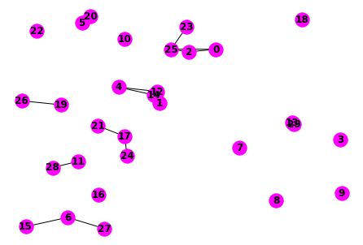

```python
GraphExercise25(r=0.05)
```

```
The simplicial complex admits 9 connected component(s).
```

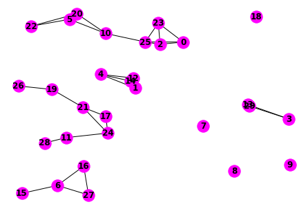

```python
GraphExercise25(r=0.1)
```

```
The simplicial complex admits 4 connected component(s).
```

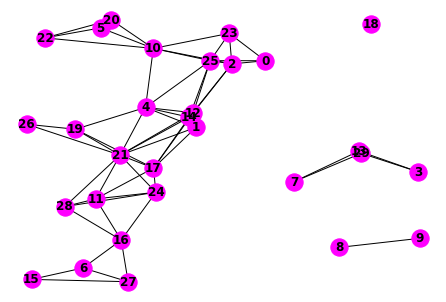

```python
GraphExercise25(r=0.2)
```

```
The simplicial complex admits 1 connected component(s).
```

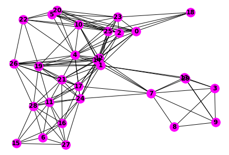

```python
GraphExercise25(r=0.5)
```

We observe that, as the value $r$ increases, the numbet of connected components decreases.

# Exercise 26

A *Erdős–Rényi random graph $\mathcal{G}(n,p)$* is a simplicial complex obtained as follows:

- add $n$ vertices $1,...,n$,
- add each edge $[a,b]$, where $a,b \in [1,n]$, to the complex with probability $p$.

Builds a function that, given $n$ and $p$, outputs a simplicial complex $\mathcal{G}(n,p)$. Observe the influence of $p$ on the number of connected components of $\mathcal{G}(10,p)$ and $\mathcal{G}(100,p)$.

*Hint:* If $V$ is a list, `itertools.combinations(V,2)` can be used to generate all the non-ordered pairs `[a,b]` in `V` (package `itertools`). The command `random.random()` can be used to generate a random number between 0 and 1, and `random.random()<p` is `True` with probability `p` (package `random`).

```python
import itertools
import random
```

```python
def GraphExercise26(n,p):
    V = list(range(n))
    simpcomplex = gudhi.SimplexTree()
    for i in range(n):
        simpcomplex.insert([i])
    for v in itertools.combinations(V,2):
        if random.random()<p:
            simpcomplex.insert(list(v))

    EulerCharacteristic(simpcomplex)
    NumberOfConnectedComponents(simpcomplex)
    DrawSimplicialComplex(simpcomplex)
```

```
The simplicial complex has Euler characteristic equal to 4.
The simplicial complex admits 5 connected component(s).
```

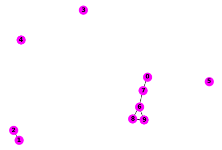

```python
GraphExercise26(n=10,p=0.2)
```

```
The simplicial complex has Euler characteristic equal to 4.
The simplicial complex admits 5 connected component(s).
```

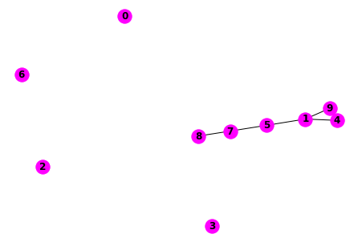

```python
GraphExercise26(n=10,p=0.2)
```

```
The simplicial complex has Euler characteristic equal to -145.
The simplicial complex admits 2 connected component(s).
```

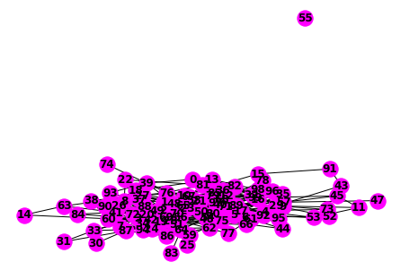

```python
GraphExercise26(n=100,p=0.05)
```